# proj_9

## House Price Estimation

Pricing is a common task among different sectors or services. For example, a real estate agent want help to objectively estimate house prices for different areas in US. He would like to give us one housing dataset to work on, and to see if machine learning technique is helpful to solve such problem. We are going to firstly check what useful information contained in the dataset, then build and train a machine learning model for estimating house prices for different areas.

The dataset contains the following columns:

- 'Avg. Area Income' - average income of the householders in the area.
- 'Avg. Area House Age' - average age of the houses in the area.
- 'Avg. Area Number of Rooms' - average number of rooms for the houses in the area.
- 'Avg. Area Number of Bedrooms' - average number of bedrooms for the houses in the area.
- 'Area Population' - population of the area.
- 'Price' - price of the house.
- 'Address' - address of the house.

```python
import pandas as pd
import numpy as np
```

### Download and Preprocess Data

We load the housing dataset to a dataframe object container. The dataset generally has two main components: features: (also known as predictors, inputs, or attributes), response: (also known as target, label, or output).

```python
df = pd.read_csv('HouseData/USA_Housing.csv')
df.head()
```

|  | Avg. Area Income | Avg. Area House Age | Avg. Area Number of Rooms | Avg. Area Number of Bedrooms | Area Population | Price | Address |
| --- | --- | --- | --- | --- | --- | --- | --- |
| 0 | 79545.458574 | 5.682861 | 7.009188 | 4.09 | 23086.800503 | 1.059034e+06 | 208 Michael Ferry Apt. 674\nLaurabury, NE 3701... |
| 1 | 79248.642455 | 6.002900 | 6.730821 | 3.09 | 40173.072174 | 1.505891e+06 | 188 Johnson Views Suite 079\nLake Kathleen, CA... |
| 2 | 61287.067179 | 5.865890 | 8.512727 | 5.13 | 36882.159400 | 1.058988e+06 | 9127 Elizabeth Stravenue\nDanieltown, WI 06482... |
| 3 | 63345.240046 | 7.188236 | 5.586729 | 3.26 | 34310.242831 | 1.260617e+06 | USS Barnett\nFPO AP 44820 |
| 4 | 59982.197226 | 5.040555 | 7.839388 | 4.23 | 26354.109472 | 6.309435e+05 | USNS Raymond\nFPO AE 09386 |

We check if there are missing values within records.

```python
df.isnull().sum()
```

```
Avg. Area Income                0
Avg. Area House Age             0
Avg. Area Number of Rooms       0
Avg. Area Number of Bedrooms    0
Area Population                 0
Price                           0
Address                         0
dtype: int64
```

We check if there may be outliers for numerical entries.

```python
df.describe(include=[np.number])
```

|  | Avg. Area Income | Avg. Area House Age | Avg. Area Number of Rooms | Avg. Area Number of Bedrooms | Area Population | Price |
| --- | --- | --- | --- | --- | --- | --- |
| count | 5000.000000 | 5000.000000 | 5000.000000 | 5000.000000 | 5000.000000 | 5.000000e+03 |
| mean | 68583.108984 | 5.977222 | 6.987792 | 3.981330 | 36163.516039 | 1.232073e+06 |
| std | 10657.991214 | 0.991456 | 1.005833 | 1.234137 | 9925.650114 | 3.531176e+05 |
| min | 17796.631190 | 2.644304 | 3.236194 | 2.000000 | 172.610686 | 1.593866e+04 |
| 25% | 61480.562388 | 5.322283 | 6.299250 | 3.140000 | 29403.928702 | 9.975771e+05 |
| 50% | 68804.286404 | 5.970429 | 7.002902 | 4.050000 | 36199.406689 | 1.232669e+06 |
| 75% | 75783.338666 | 6.650808 | 7.665871 | 4.490000 | 42861.290769 | 1.471210e+06 |
| max | 107701.748378 | 9.519088 | 10.759588 | 6.500000 | 69621.713378 | 2.469066e+06 |

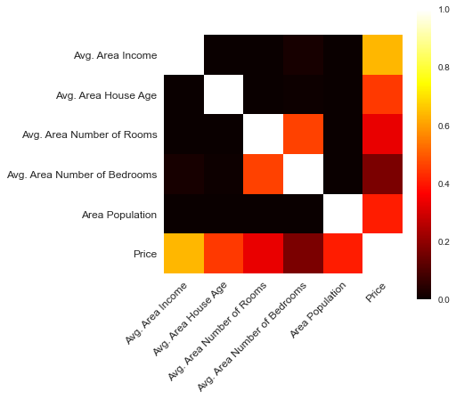

```python
import matplotlib.pyplot as plt
plt.style.use('seaborn')

corr = df.corr()
fig, ax = plt.subplots(figsize=(6,6))
plt.imshow(corr, cmap='hot', interpolation ='none', vmin=0, vmax=1)
plt.grid(None)
plt.colorbar()
plt.xticks(range(len(corr)), corr.columns, fontsize=12)
plt.yticks(range(len(corr)), corr.columns, fontsize=12)
plt.setp(ax.get_xticklabels(), rotation=45, ha="right", rotation_mode="anchor")
plt.show()
```

### Set up the Training and Testing Datasets

```python
from sklearn.model_selection import train_test_split
X = df[['Avg. Area Income', 'Avg. Area House Age', 'Avg. Area Number of Rooms',
        'Avg. Area Number of Bedrooms', 'Area Population']]
y = df['Price']
X_train, X_test, y_train, y_test = train_test_split(X, y, test_size=0.2, random_state=1)
```

### Define and Train the Model

```python
from sklearn.linear_model import LinearRegression
lm = LinearRegression()
lm.fit(X_train,y_train)
```

```
LinearRegression()
```

### Evaluate the Model

```python
coeff = pd.DataFrame(lm.coef_,index=X.columns,columns=['Coefficient'])
coeff
```

|  | Coefficient |
| --- | --- |
| Avg. Area Income | 21.666735 |
| Avg. Area House Age | 164990.051829 |
| Avg. Area Number of Rooms | 120784.238317 |
| Avg. Area Number of Bedrooms | 1542.524676 |
| Area Population | 15.150370 |

A common method of measuring the accuracy of regression models is to use the $R^2$, which can be determined using the model's score method.

```python
lm.score(X_train, y_train)
```

```
0.9170083707375688
```

Mean Absolute Error (MAE): $\frac{1}{n}\sum_{i=1}^{n} |y_i-\hat{y_i}|$

Mean Squared Error (MSE): $\frac{1}{n}\sum_{i=1}^{n} (y_i-\hat{y_i})^2$

Root Mean Squared Error (RMSE): $\sqrt{\frac{1}{n}\sum_{i=1}^{n} (y_i-\hat{y_i})^2}$

```python
y_train_pred = lm.predict(X_train)
```

```python
from sklearn import metrics
# All of these are loss functions because we want to minimize them
print(f'MAE: {metrics.mean_absolute_error(y_train, y_train_pred):.3f}')
print(f'MSE: {metrics.mean_squared_error(y_train, y_train_pred):.3f}')
print(f'RMSE: {np.sqrt(metrics.mean_squared_error(y_train, y_train_pred)):.3f}')
```

```
MAE: 81076.254
MSE: 10141842650.260
RMSE: 100706.716
```

```python
y_test_pred = lm.predict(X_test)
```

In the below Scatterplot, we can see the data points are generally in a line form, which means the linear model can do a reasonably good job for price estimation. For better accuracy, more sophisticated non-linear models need to be looked into and evaluated in future.

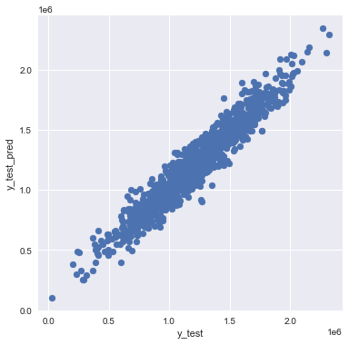

```python
plt.figure(figsize=(6,6))
plt.scatter(y_test,y_test_pred)
plt.xlabel('y_test')
plt.ylabel('y_test_pred')
plt.show()
```

```python
lm.score(X_test, y_test)
```

```
0.9215935236936348
```